# R_for_Data_Science

Alibek

September 6, 2018

# Chapter 1. Data Visualization with ggplot2.

## Introduction

The most effective way to grasp some insights from data is to visualize it. The most effective library to visualize data is ggplot2. “gg” stands for grammar of graphics. To use ggplot2 we need to initialize it.

```r
library(tidyverse)
```

This one line of code loads different packages to analyze and visualize data. There’s some conflicts in function names of dplyr package and core R functions. To specify function from package we need to write package::function. For example: dplyr::filter().

## First Steps

Let’s use ggplot2 package to answer a question: do cars with big engine use more fuel than cars with small engine? It is intuitive that they do, but let’s prove it visually. In addition, we can find out if releationship between engine size and fuel efficiency is linear or nonlinear. We used preload data from ggplot2 - mpg. It is observations of 234 cars from US Environment Protection Agency.

```r
df = ggplot2::mpg
head(df)
```

```
## # A tibble: 6 x 11
##   manufacturer model displ  year   cyl trans drv     cty   hwy fl    class
##   <chr>        <chr> <dbl> <int> <int> <chr> <chr> <int> <int> <chr> <chr>
## 1 audi         a4      1.8  1999     4 auto… f        18    29 p     comp…
## 2 audi         a4      1.8  1999     4 manu… f        21    29 p     comp…
## 3 audi         a4      2    2008     4 manu… f        20    31 p     comp…
## 4 audi         a4      2    2008     4 auto… f        21    30 p     comp…
## 5 audi         a4      2.8  1999     6 auto… f        16    26 p     comp…
## 6 audi         a4      2.8  1999     6 manu… f        18    26 p     comp…
```

## Creating a ggplot

The most effective way to show relationship between two variables is scatter plot. We use *displ* as x axis and *hwy* as y axis.

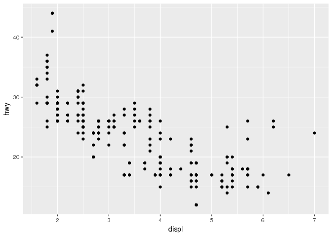

```r
ggplot(df) +
    geom_point(mapping = aes(x = displ, y = hwy))
```

The scatter plot shows negative relationship between fuel efficiency and engine size. Which means that cars with bigger engines consume more fuel. *ggplot()* function creates empty graph, then with *geom_point()* function we add points layer to empty graph.

## Exercise

Make scatter plot *hwy* vs. *cyl*.

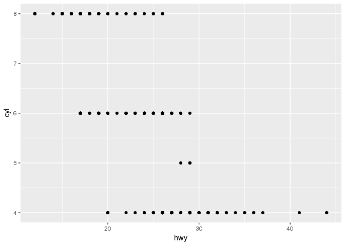

```r
ggplot(data = mpg) +
    geom_point(mapping = aes(x = hwy, y = cyl))
```

Make scatter plot *class* vs. *drv*.

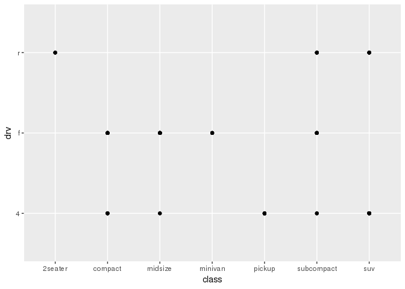

```r
ggplot(data = mpg) +
    geom_point(mapping = aes(x = class, y =drv))
```

## Aesthetic Mappings

*The greatest value of a picture is when it forces us to notice what we never expected to see. -John Tukey*

Aesthetic function maps data into axis, also it can describe size of points, shape of points and color of points. Below, we’ll plot same scatter plot with different colors for class of cars.

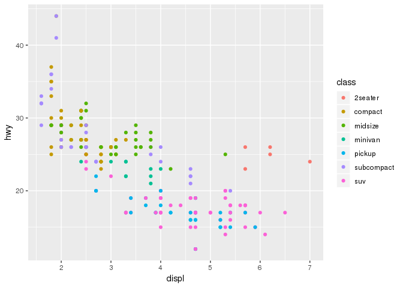

```r
ggplot(data = mpg) +
    geom_point(mapping = aes(x = displ, y = hwy, color = class))
```

Besides colors of class, we can map also size of a points:

```
## Warning: Using size for a discrete variable is not advised.
```

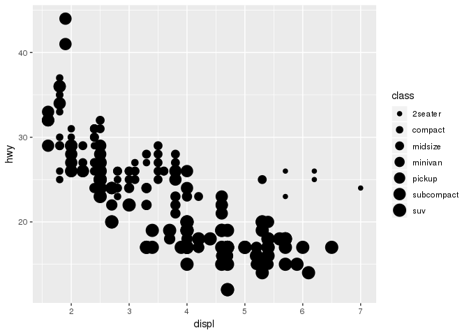

```r
ggplot(data = mpg) +
    geom_point(mapping = aes(x = displ, y = hwy, size = class))
```

There’s warning that setting size of points to class is not good idea, since class variable is unordered categorical varaible. Transparency of points and shape of points can be mapped in aes function too.

```
## Warning: Using alpha for a discrete variable is not advised.
```

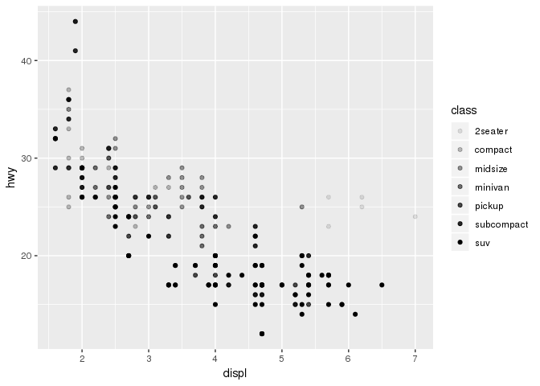

```r
ggplot(data = mpg) +
    geom_point(mapping = aes(x = displ, y = hwy, alpha = class))
```

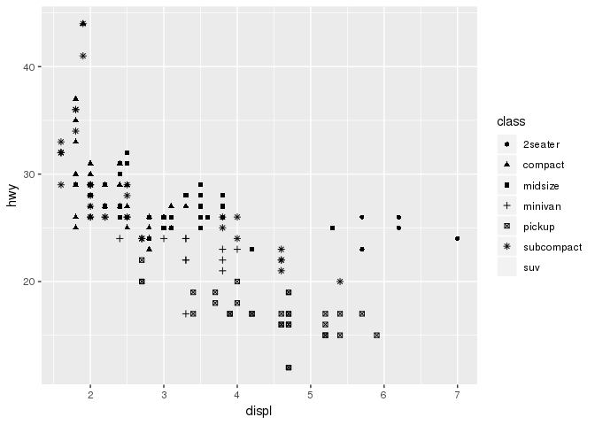

```r
ggplot(data = mpg) +
    geom_point(mapping = aes(x = displ, y = hwy, shape = class))
```

There’s only 6 type of shapes, and we have 7 categories for a class variable, so suv points didn’t assign to any shape points. We can set aesthetic properties, for example we can specify color of points:

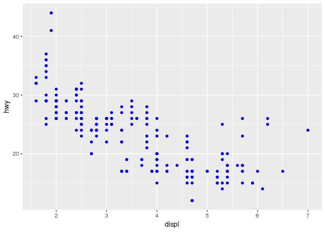

```r
ggplot(data = mpg) +
    geom_point(mapping = aes(x = displ, y = hwy), color = 'blue')
```

## Facets

To split categorical data into different plots we can use different facets - subplots that use different subsets of data. Example:

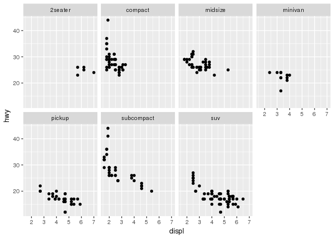

```r
ggplot(data = mpg) +
    geom_point(mapping = aes(x = displ, y = hwy)) +
    facet_wrap(~ class, nrow = 2)
```

To facet a plot on the combination of categorical data we should use *facet_frid()* function. Example:

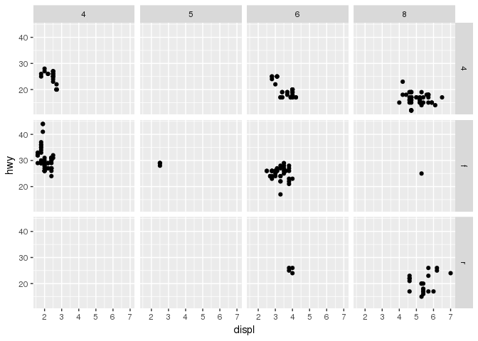

```r
ggplot(data = mpg) +
    geom_point(mapping = aes(x = displ, y = hwy)) +
    facet_grid(drv ~ cyl)
```

## Geometric Objects

Same x and y variables can be plotted in different ways. It depends on geom function you put it. Example:

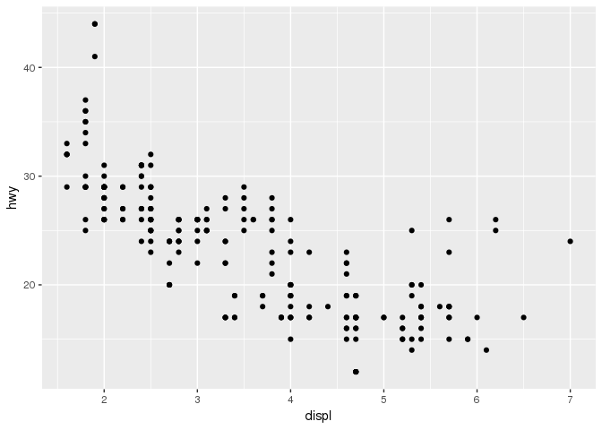

```r
p = ggplot(data = mpg)

p +
    geom_point(mapping = aes(x = displ, y = hwy))
```

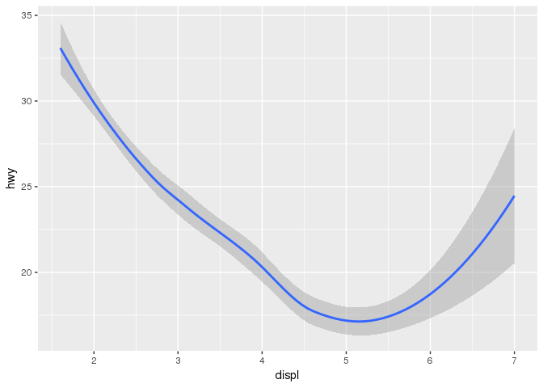

```r
p +
    geom_smooth(mapping = aes(x = displ, y = hwy))
```

Not every argument in *geom_point()* function works in *geom_smooth()* function. You can not set shape of line, howerver you can set line type.

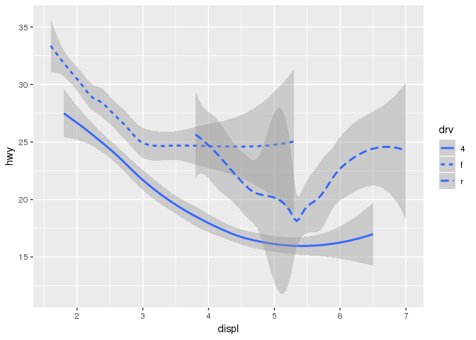

```r
p +
    geom_smooth(mapping = aes(x = displ, y = hwy, linetype = drv))
```

ggplot2 provides over 30 geoms, and extension package contains even more. We can display multiple geoms:

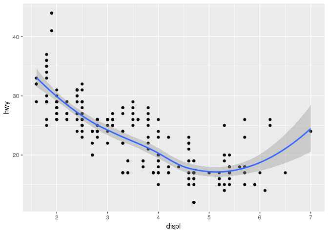

```r
p +
    geom_point(mapping = aes(x = displ, y = hwy)) +
    geom_smooth(mapping = aes(x = displ, y = hwy))
```

Instead of writing x and y in every geom, we can put them inside ggplot, which set these axes as global for every geom:

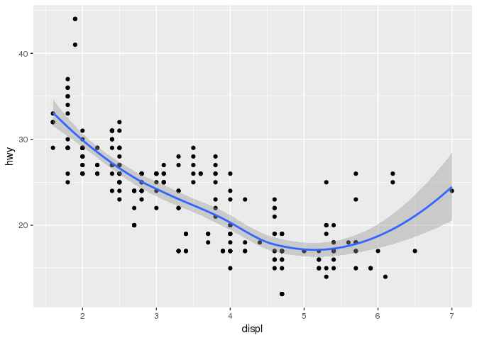

```r
p = ggplot(data = mpg, mapping = aes(x = displ, y = hwy))

p +
    geom_point() +
    geom_smooth()
```

It is exact same plot as previous one. Still we can add some aesthetics into geom functions:

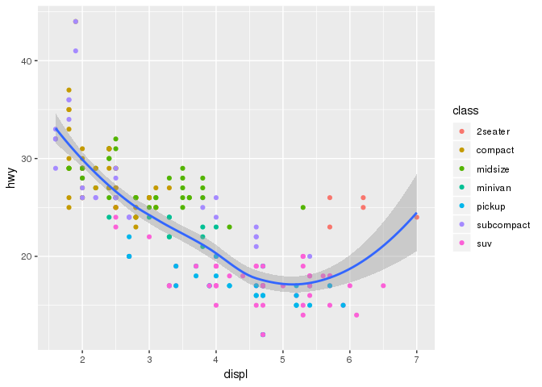

```r
p +
    geom_point(mapping = aes(color = class)) +
    geom_smooth()
```

Local variables or data overwrite global variables or data.

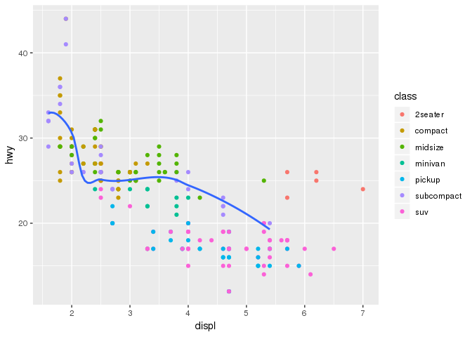

```r
p +
    geom_point(mapping = aes(color = class)) +
    geom_smooth(data = filter(df, class == "subcompact"), se = FALSE)
```

## Statistical Transformations

Bar charts can reveal something interesting about data. Below is a chart which shows number of diamonds grouped by their cuts.

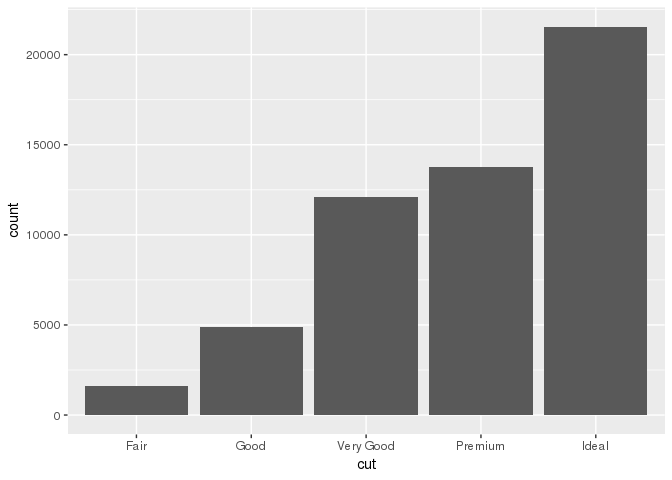

```r
p = ggplot(data = diamonds)

p +
    geom_bar(mapping = aes(x = cut))
```

This chart shows that in dataset, there’s more diamonds with high-quality cuts. Instead of count, we can specify proportions of diamond in each cut.

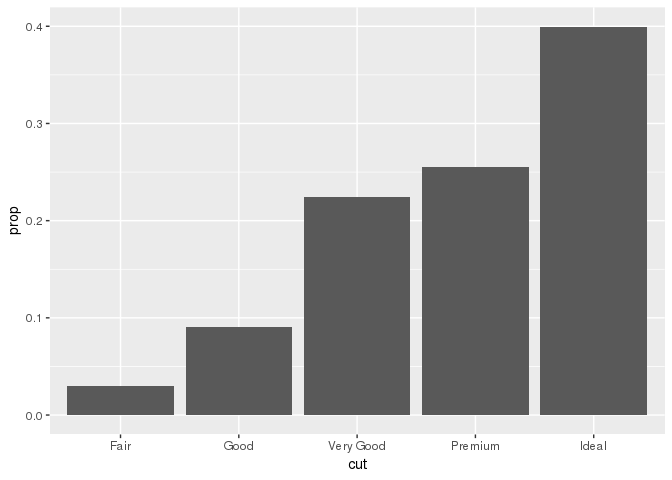

```r
p +
    geom_bar(mapping = aes(x = cut, y = ..prop.., group = 1))
```

We can map some summary stats to the chart with *stat_summary()* function:

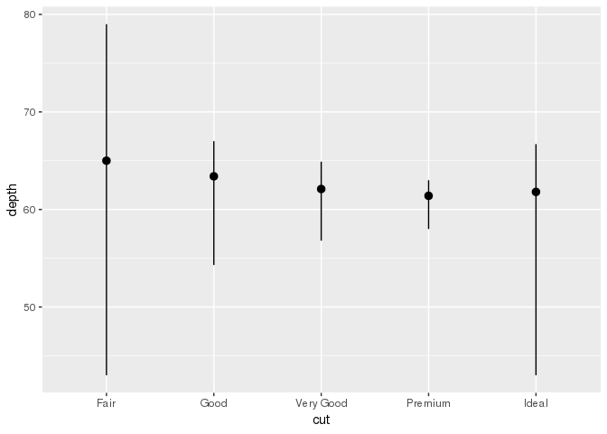

```r
p +
    stat_summary(mapping = aes(x = cut, y = depth), fun.ymin = min, fun.ymax = max, fun.y = median)
```

## Position Adjustments

You can fill barcharts with colors. If you fill with another variable, like clarity, barchart automaticallly will be stacked:

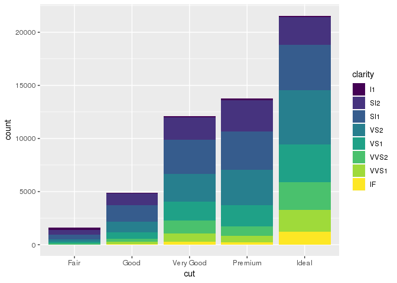

```r
p +
    geom_bar(mapping = aes(x = cut, fill = clarity))
```

Attribute *position* in geom_bar() function will make stacked barplot with same height:

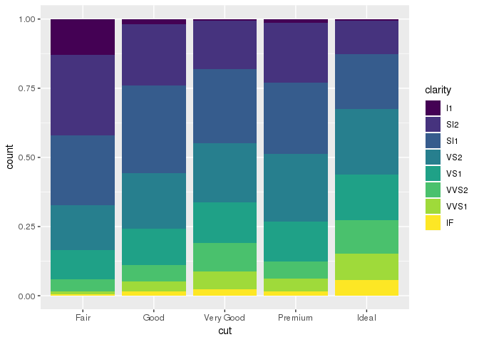

```r
p +
    geom_bar(mapping = aes(x = cut, fill = clarity), position = "fill")
```

Position ‘dodge’ place bars beside each other:

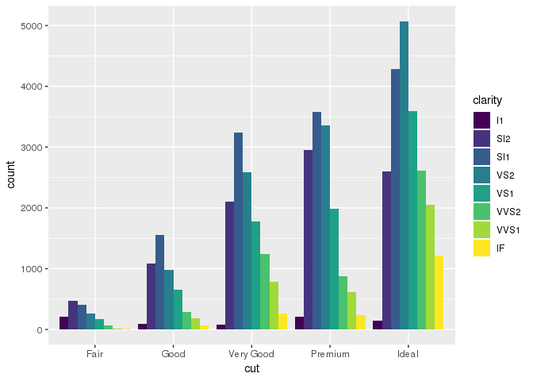

```r
p +
    geom_bar(aes(x = cut, fill = clarity), position = "dodge")
```

Not useful for barcharts, but very useful in scatterplots is adding some jitter. Since some points can overlap each other, we will add some small amount of noise to the position of points:

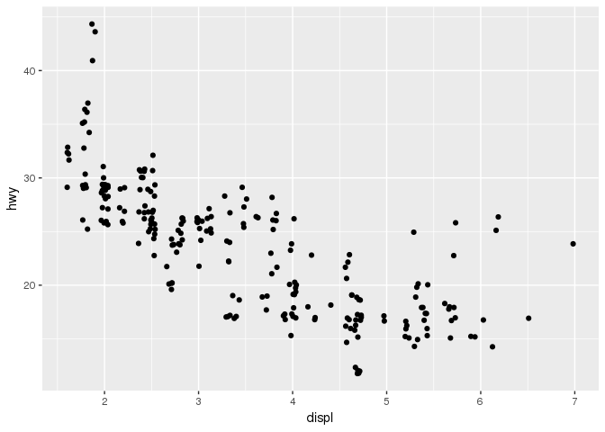

```r
ggplot(data = mpg) +
    geom_point(mapping = aes(x = displ, y = hwy), position = 'jitter')
```

Instead of defining position in geom_point() function, ggplot2 has handy geom_jitter() function, which is pretty much same:

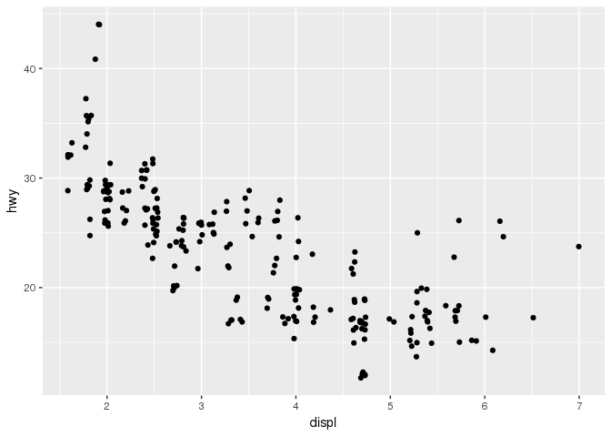

```r
ggplot(data = mpg) +
    geom_jitter(mapping = aes(x = displ, y = hwy))
```

## Coordinate Systems

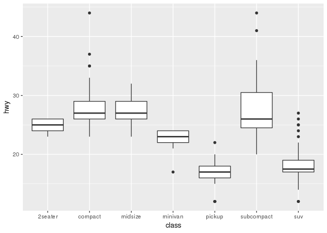

```r
ggplot(data = mpg, mapping = aes(x = class, y = hwy)) +
    geom_boxplot()
```

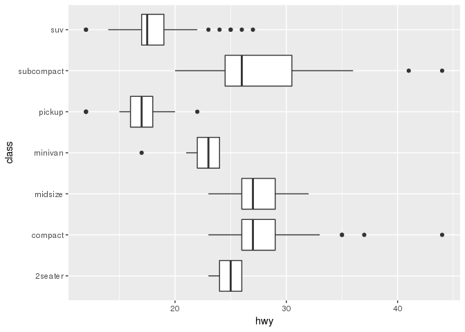

```r
ggplot(data = mpg, mapping = aes(x = class, y = hwy)) +
    geom_boxplot() +
    coord_flip()
```

Polar coordinates can interestingly show barcharts:

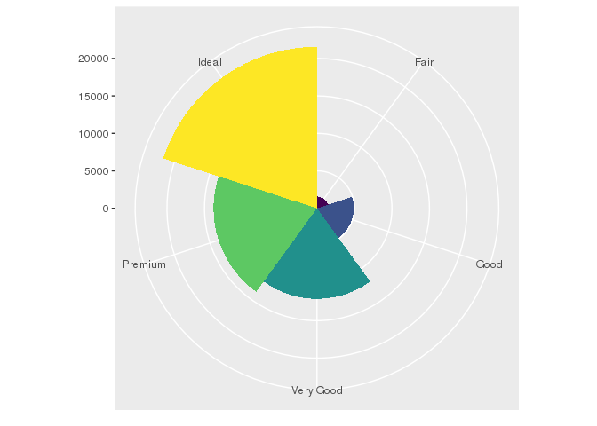

```r
ggplot(data = diamonds) +
    geom_bar(mapping = aes(x = cut, fill = cut), show.legend = F, width = 1) +
    theme(aspect.ratio = 1) +
    labs(x = NULL, y = NULL) +
    coord_flip() +
    coord_polar()
```